# Lab 9: Multiple linear regression

## Exercice 5

5. Let’s see if the apparent trend in the plot is something more than natural variation. Fit a linear model called `m_bty` to predict average professor score by average beauty rating. Write out the equation for the linear model and interpret the slope. Is average beauty score a statistically significant predictor? Does it appear to be a practically significant predictor?

Add the line of the bet fit model to your plot using the following:

```r
m_bty <- lm(score ~ bty_avg, data = evals)
summary(m_bty)
```

```
##
## Call:
## lm(formula = score ~ bty_avg, data = evals)
##
## Residuals:
##     Min      1Q  Median      3Q     Max
## -1.9246 -0.3690  0.1420  0.3977  0.9309
##
## Coefficients:
##             Estimate Std. Error t value Pr(>|t|)
## (Intercept)  3.88034    0.07614   50.96  < 2e-16 ***
## bty_avg      0.06664    0.01629    4.09 5.08e-05 ***
## ---
## Signif. codes:  0 '***' 0.001 '**' 0.01 '*' 0.05 '.' 0.1 ' ' 1
##
## Residual standard error: 0.5348 on 461 degrees of freedom
## Multiple R-squared:  0.03502,    Adjusted R-squared:  0.03293
## F-statistic: 16.73 on 1 and 461 DF,  p-value: 5.083e-05
```

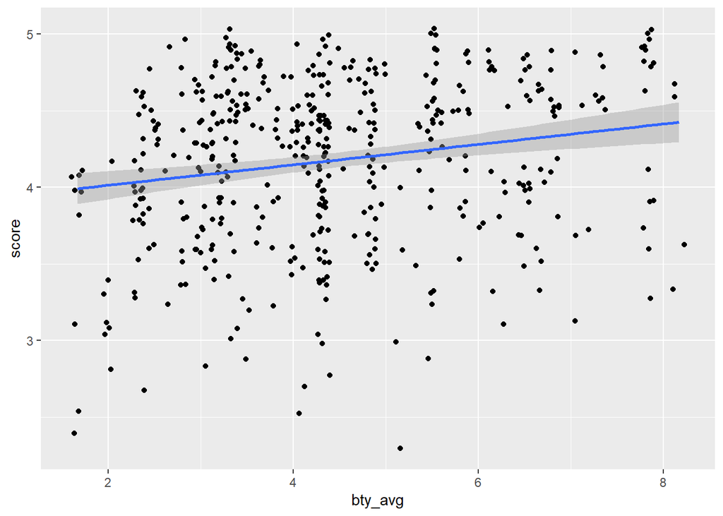

```r
ggplot(data = evals, aes(x = bty_avg, y = score)) +
  geom_jitter() +
  geom_smooth(method = "lm")
```

The blue line is the model. The shaded gray area around the line tells you about the variability you might expect in your predictions. To turn that off, use `se = FALSE`.

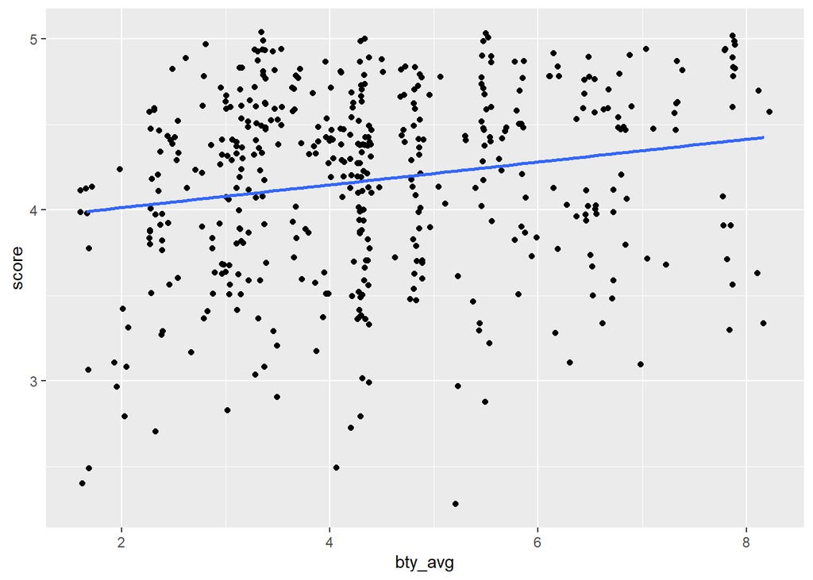

```r
ggplot(data = evals, aes(x = bty_avg, y = score)) +
  geom_jitter() +
  geom_smooth(method = "lm", se = FALSE)
```

### Answer

Equation for the linear model. y = ax + b, where y = score, a = 0.06664, x = average beauty (bty_avg), b = 3.88034.

[output not shown]

## Exercice 6

6. Use residual plots to evaluate whether the conditions of least squares regression are reasonable. Provide plots and comments for each one (see the Simple Regression Lab for a reminder of how to make these).

```r
library(statsr)
evals2 <- select(evals, bty_avg, score)
head(evals2)
```

```
## # A tibble: 6 x 2
##   bty_avg score
##     <dbl> <dbl>
## 1       5   4.7
## 2       5   4.1
## 3       5   3.9
## 4       5   4.8
## 5       3   4.6
## 6       3   4.3
```

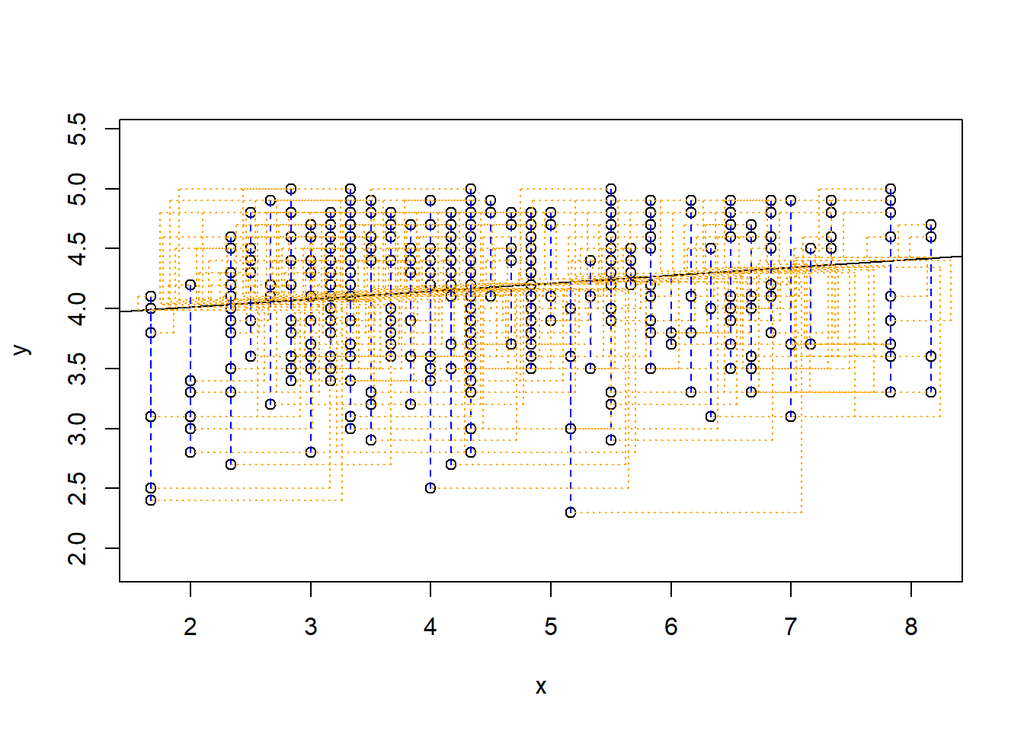

```
## Click two points to make a line.

## Call:
## lm(formula = y ~ x, data = pts)
##
## Coefficients:
## (Intercept)            x
##     3.88034      0.06664
##
## Sum of Squares:  131.868
```

```r
plot_ss(x = evals2$bty_avg, y = evals2$score , showSquares = TRUE)
```

Just by looking at the regression line and squared residuals, we can tell that many points off. Let’s recall that the Least Squares Regression Line is the line that makes the vertical distance from the data points to the regression line as small as possible. It’s called a “least squares” because the best line of fit is one that minimizes the variance (the sum of squares of the errors).

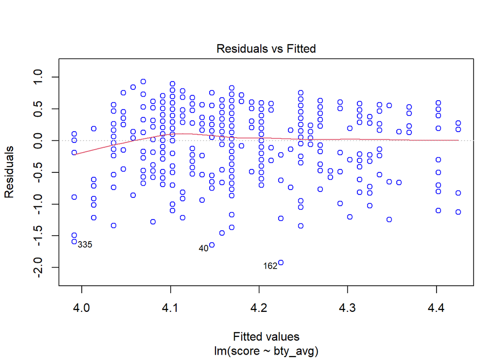

```r
evals1_fit <- lm(score~bty_avg, data = evals2)
plot(evals1_fit, which = 1, col = c("blue"))
```

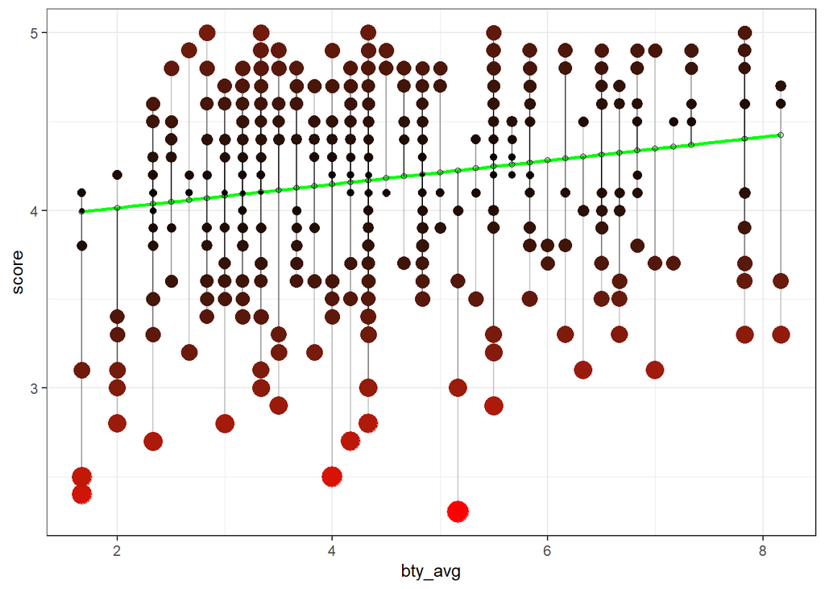

```r
#summary(evals1_fit)
# let's add predicted and residual into data
evals2$predicted <- predict(evals1_fit)
evals2$residuals <- residuals(evals1_fit)
# Let's take a look at evals1_fit
#glimpse(evals1_fit)

ggplot (evals2, aes(x = bty_avg, y = score)) +
  geom_smooth(method = "lm", se = FALSE, color = "green") +
  geom_segment(aes(xend = bty_avg, yend = predicted), alpha = .2) +
  geom_point(aes(color = abs(residuals), size = abs(residuals))) +
  scale_color_continuous(low = "black", high = "red") +
  guides(color = FALSE, size = FALSE) +
  geom_point(aes(y = predicted), shape = 1) +
  theme_bw()
```

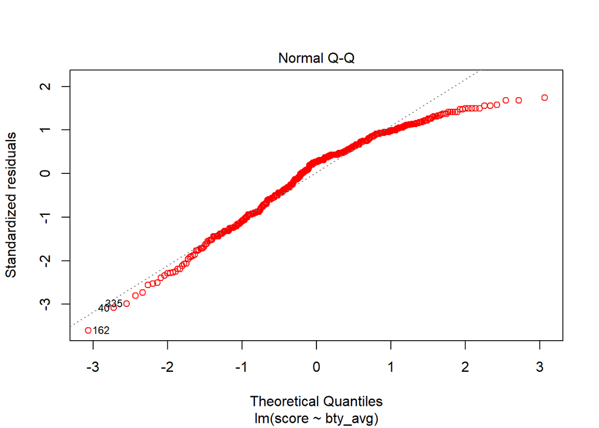

```r
plot(evals1_fit, which = 2, col = c("red")) #another way of plotting Q-Q plot
```

```r
#qqnorm(evals1$residuals)
#qqline(evals1$residuals)
```

Based on the normal Q-Q plot , the residuals show a deviation from the line around the tails. This is an indicator that data is not normally distributed.

## Multiple linear regression

The data set contains several variables on the beauty score of the professor: individual ratings from each of the six students who were asked to score the physical appearance of the professors and the average of these six scores. Let’s take a look at the relationship between one of these scores and the average beauty score.

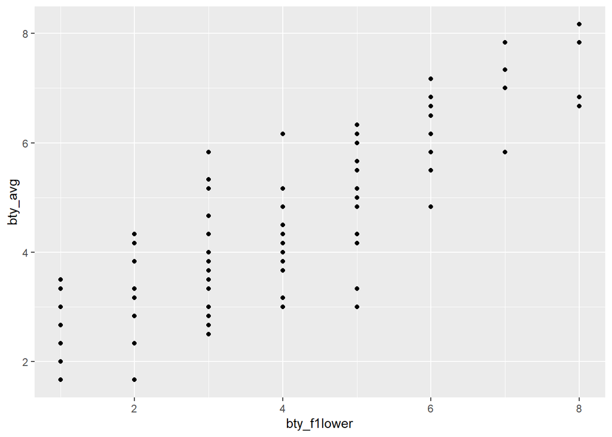

```r
ggplot(data = evals, aes(x = bty_f1lower, y = bty_avg)) +
  geom_point()
```

```r
evals %>%
  summarise(cor(bty_avg, bty_f1lower))
```

```
## # A tibble: 1 x 1
##   `cor(bty_avg, bty_f1lower)`
##                         <dbl>
## 1                       0.844
```

As expected, the relationship is quite strong—after all, the average score is calculated using the individual scores. You can actually look at the relationships between all beauty variables (columns 13 through 19) using the following command:

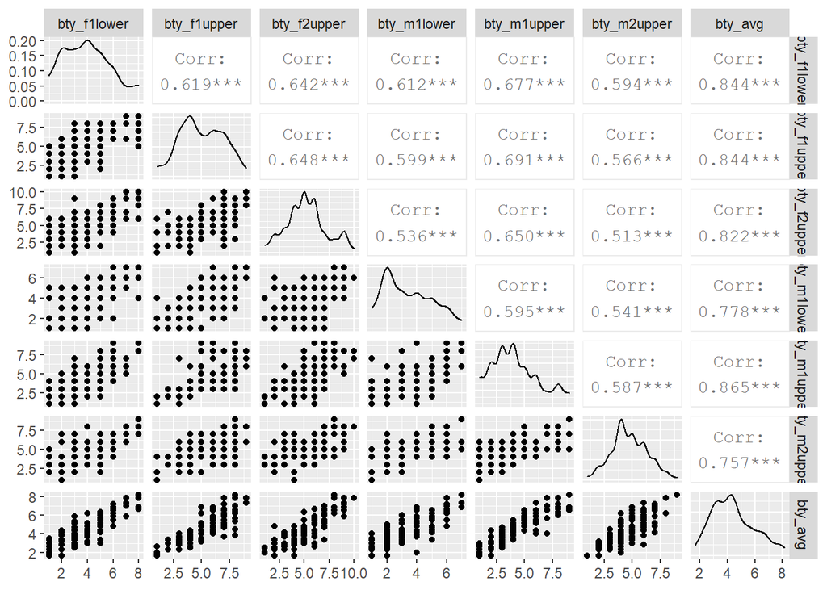

```r
evals %>%
  select(contains("bty")) %>%
  ggpairs()
```

These variables are collinear (correlated), and adding more than one of these variables to the model would not add much value to the model. In this application and with these highly-correlated predictors, it is reasonable to use the average beauty score as the single representative of these variables.

In order to see if beauty is still a significant predictor of professor score after you’ve accounted for the professor’s gender, you can add the gender term into the model.

```r
m_bty_gen <- lm(score ~ bty_avg + gender, data = evals)
summary(m_bty_gen)
```

```
##
## Call:
## lm(formula = score ~ bty_avg + gender, data = evals)
##
## Residuals:
##     Min      1Q  Median      3Q     Max
## -1.8305 -0.3625  0.1055  0.4213  0.9314
##
## Coefficients:
##             Estimate Std. Error t value Pr(>|t|)
## (Intercept)  3.74734    0.08466  44.266  < 2e-16 ***
## bty_avg      0.07416    0.01625   4.563 6.48e-06 ***
## gendermale   0.17239    0.05022   3.433 0.000652 ***
## ---
## Signif. codes:  0 '***' 0.001 '**' 0.01 '*' 0.05 '.' 0.1 ' ' 1
##
## Residual standard error: 0.5287 on 460 degrees of freedom
## Multiple R-squared:  0.05912,    Adjusted R-squared:  0.05503
## F-statistic: 14.45 on 2 and 460 DF,  p-value: 8.177e-07
```

## Exercice 7

7. P-values and parameter estimates should only be trusted if the conditions for the regression are reasonable. Verify that the conditions for this model are reasonable using diagnostic plots.

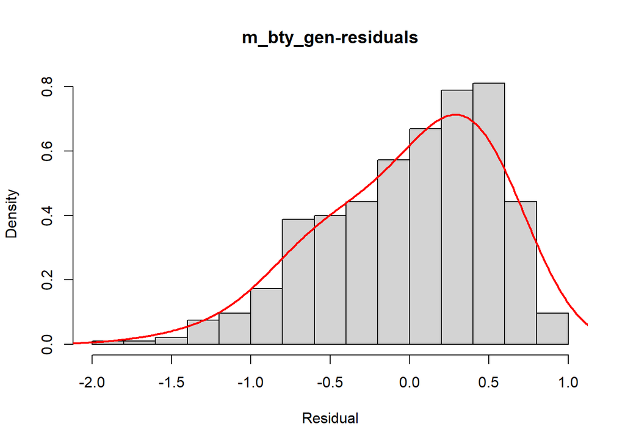

```r
hist(m_bty_gen$residuals, prob = TRUE, breaks = 11,  main = "m_bty_gen-residuals", xlab = "Residual")
lines(density(m_bty_gen$residuals, adjust = 1.8), col = "Red", lwd = 2)
```

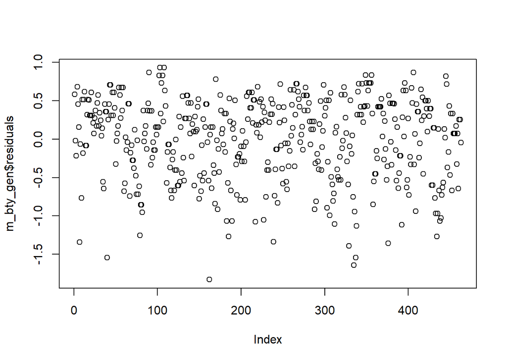

```r
plot(m_bty_gen$residuals)
```

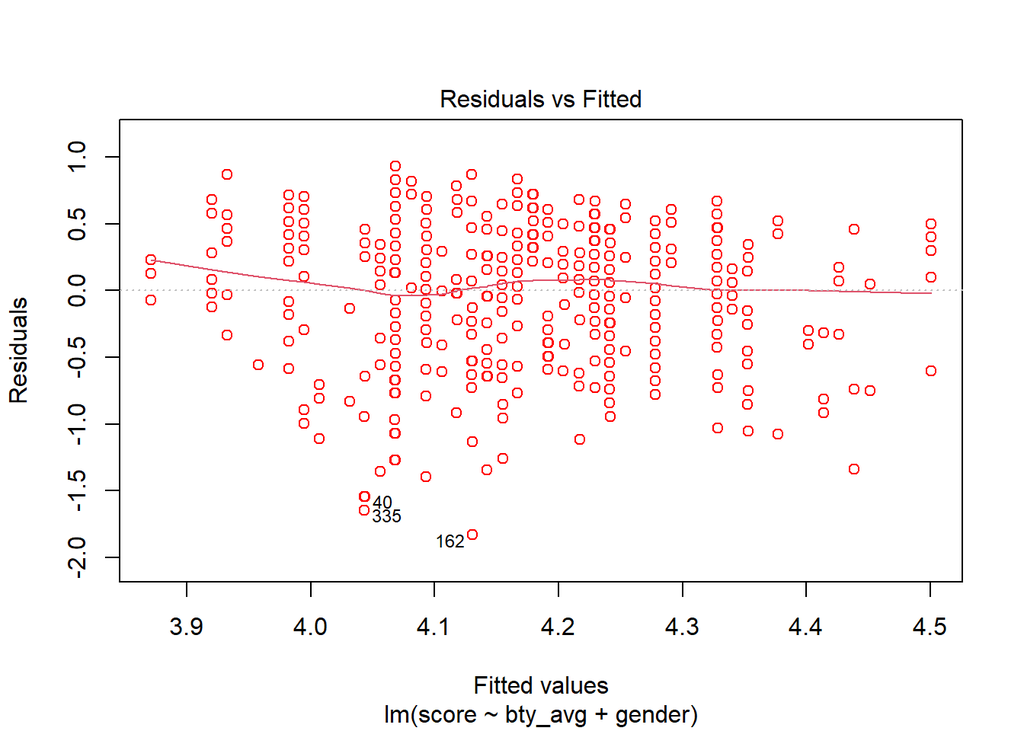

```r
plot(m_bty_gen, which = 1, col = c("red"))
```

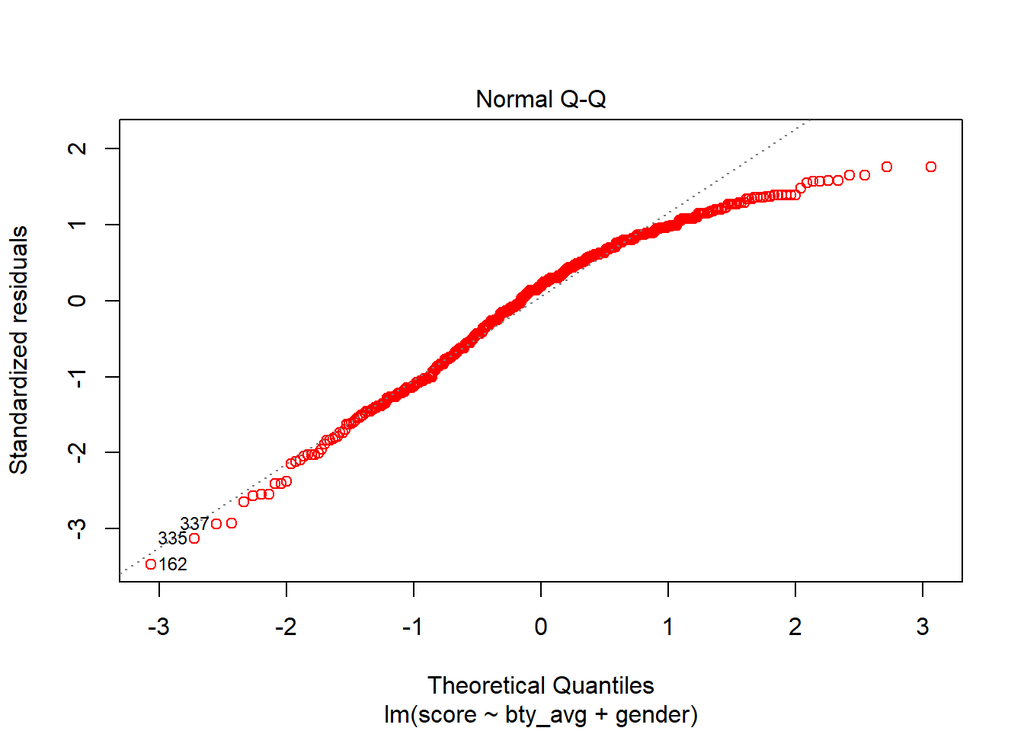

```r
plot(m_bty_gen, which = 2, col = c("red"))
```

The histogram of the residual shows a left skewed distributed data. this is not a normal distributed data. the residuals show a deviation from the line around the tails. This is an indicator that data is not normally distributed. The We are bit confused…

## Exercice 8

8. Is `bty_avg` still a significant predictor of `score`? Has the addition of `gender` to the model changed the parameter estimate for `bty_avg`?

We are bit confused. Adding gender to the model decreased the p-value from 5.083e-05 to 8.177e-07

Note that the estimate for `gender` is now called `gendermale`. You’ll see this name change whenever you introduce a categorical variable. The reason is that R recodes `gender` from having the values of `male` and `female` to being an indicator variable called `gendermale` that takes a value of $0$ for female professors and a value of $1$ for male professors. (Such variables are often referred to as “dummy” variables.)

As a result, for female professors, the parameter estimate is multiplied by zero, leaving the intercept and slope form familiar from simple regression.

$$\begin{aligned}
\widehat{score} &= \hat{\beta}_0 + \hat{\beta}_1 \times bty\_avg + \hat{\beta}_2 \times (0) \\
&= \hat{\beta}_0 + \hat{\beta}_1 \times bty\_avg\end{aligned}$$

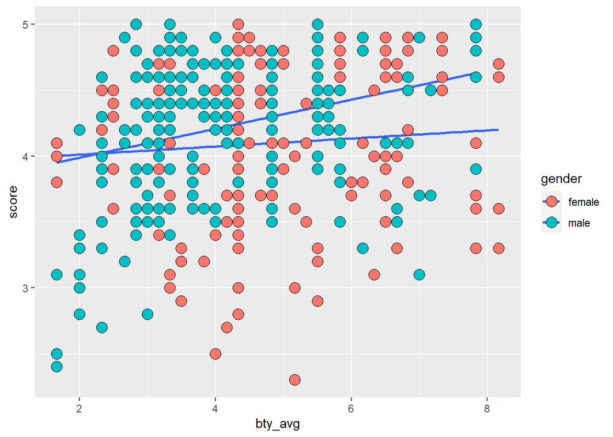

```r
byt_df <- select(evals, gender, bty_avg, score)

ggplot(byt_df, aes(x = bty_avg, y = score, fill = gender)) +
  geom_smooth(method = "lm" , formula = y ~ x , se = FALSE) +
  geom_point(size = 4, shape = 21)
```

## Exercice 9

9. What is the equation of the line corresponding to those with color pictures? (*Hint:* For those with color pictures, the parameter estimate is multiplied by 1.) For two professors who received the same beauty rating, which color picture tends to have the higher course evaluation score? ### Answer:
   $$\begin{aligned}
   \widehat{score} &= \hat{\beta}_0 + \hat{\beta}_1 \times bty\_avg + \hat{\beta}_2 \times (x2) \\
   &= 3.74734 + 0.07416\times bty\_avg + 0.17239\times (x2)\end{aligned}$$
   ### For two professors who received the same beauty rating,male professor tends to have the higher course evaluation score (strange from experience).

The decision to call the indicator variable `gendermale` instead of `genderfemale` has no deeper meaning. R simply codes the category that comes first alphabetically as a $0$. (You can change the reference level of a categorical variable, which is the level that is coded as a 0, using the`relevel()` function. Use `?relevel` to learn more.)

## Exercice 10

10. Create a new model called `m_bty_rank` with `gender` removed and `rank` added in. How does R appear to handle categorical variables that have more than two levels? Note that the rank variable has three levels: `teaching`, `tenure track`, `tenured`.

```r
m_bty_rank <- lm(score~bty_avg + rank, data = evals)
summary(m_bty_rank)
```

```
##
## Call:
## lm(formula = score ~ bty_avg + rank, data = evals)
##
## Residuals:
##     Min      1Q  Median      3Q     Max
## -1.8713 -0.3642  0.1489  0.4103  0.9525
##
## Coefficients:
##                  Estimate Std. Error t value Pr(>|t|)
## (Intercept)       3.98155    0.09078  43.860  < 2e-16 ***
## bty_avg           0.06783    0.01655   4.098 4.92e-05 ***
## ranktenure track -0.16070    0.07395  -2.173   0.0303 *
## ranktenured      -0.12623    0.06266  -2.014   0.0445 *
## ---
## Signif. codes:  0 '***' 0.001 '**' 0.01 '*' 0.05 '.' 0.1 ' ' 1
##
## Residual standard error: 0.5328 on 459 degrees of freedom
## Multiple R-squared:  0.04652,    Adjusted R-squared:  0.04029
## F-statistic: 7.465 on 3 and 459 DF,  p-value: 6.88e-05
```

```r
head(evals$rank)
```

```
## [1] tenure track tenure track tenure track tenure track tenured
## [6] tenured
## Levels: teaching tenure track tenured
```

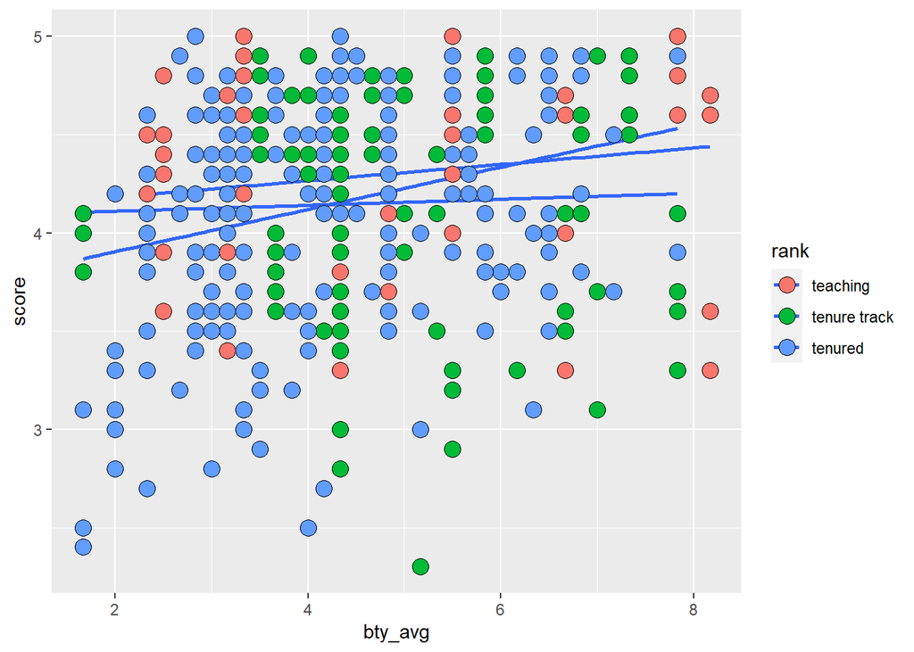

```r
byt_df1 <- select(evals, rank, bty_avg, score)

ggplot(byt_df1, aes(x = bty_avg, y = score, fill = rank)) +
  geom_smooth(method = "lm" , formula = y ~ x , se = FALSE) +
  geom_point(size = 4, shape = 21)
```

### R appear to handle categorical variable that have more than two levels well. In this case rank as 03 levels and teaching parameter estimate is multiplied by 0 while tenured and tenure track are multiplied by 1 respectively. We get the following equation of the line.

$$\begin{aligned}
\widehat{score} &= \hat{\beta}_0 + \hat{\beta}_1 \times bty\_avg + \hat{\beta}_2 \times (x2) + \hat{\beta}_3 \times (x3) \\
&= 3.98155 + 0.06783\times bty\_avg -0.16070 \times (x2) - 0.12623\times (x3)\end{aligned}$$

The interpretation of the coefficients in multiple regression is slightly different from that of simple regression. The estimate for `bty_avg` reflects how much higher a group of professors is expected to score if they have a beauty rating that is one point higher *while holding all other variables constant*. In this case, that translates into considering only professors of the same rank with `bty_avg` scores that are one point apart.

## The search for the best model

We will start with a full model that predicts professor score based on rank, gender, ethnicity, language of the university where they got their degree, age, proportion of students that filled out evaluations, class size, course level, number of professors, number of credits, average beauty rating, outfit, and picture color.

## Exercice 11

11. Which variable would you expect to have the highest p-value in this model? Why? *Hint:* Think about which variable would you expect to not have any association with the professor score. ### Answer: We would expect the cls_level (class level:lower, upper). We think class level has no association with the professor score because professor score is independent of class level. We think each student regardless of his/her level care more about how good the professor is. The only apprehension on this choice is the judgement a student might have. Maybe students from upper level are more objective than those from lower level. This sounds more like a bias assumption since there is no fact to prove it.

Let’s run the model…

```r
#?evals
m_full <- lm(score ~ rank + gender + ethnicity + language + age + cls_perc_eval
             + cls_students + cls_level + cls_profs + cls_credits + bty_avg
             + pic_outfit + pic_color, data = evals)
summary(m_full)
```

```
##
## Call:
## lm(formula = score ~ rank + gender + ethnicity + language + age +
##     cls_perc_eval + cls_students + cls_level + cls_profs + cls_credits +
##     bty_avg + pic_outfit + pic_color, data = evals)
##
## Residuals:
##      Min       1Q   Median       3Q      Max
## -1.77397 -0.32432  0.09067  0.35183  0.95036
##
## Coefficients:
##                         Estimate Std. Error t value Pr(>|t|)
## (Intercept)            4.0952141  0.2905277  14.096  < 2e-16 ***
## ranktenure track      -0.1475932  0.0820671  -1.798  0.07278 .
## ranktenured           -0.0973378  0.0663296  -1.467  0.14295
## gendermale             0.2109481  0.0518230   4.071 5.54e-05 ***
## ethnicitynot minority  0.1234929  0.0786273   1.571  0.11698
## languagenon-english   -0.2298112  0.1113754  -2.063  0.03965 *
## age                   -0.0090072  0.0031359  -2.872  0.00427 **
## cls_perc_eval          0.0053272  0.0015393   3.461  0.00059 ***
## cls_students           0.0004546  0.0003774   1.205  0.22896
## cls_levelupper         0.0605140  0.0575617   1.051  0.29369
## cls_profssingle       -0.0146619  0.0519885  -0.282  0.77806
## cls_creditsone credit  0.5020432  0.1159388   4.330 1.84e-05 ***
## bty_avg                0.0400333  0.0175064   2.287  0.02267 *
## pic_outfitnot formal  -0.1126817  0.0738800  -1.525  0.12792
## pic_colorcolor        -0.2172630  0.0715021  -3.039  0.00252 **
## ---
## Signif. codes:  0 '***' 0.001 '**' 0.01 '*' 0.05 '.' 0.1 ' ' 1
##
## Residual standard error: 0.498 on 448 degrees of freedom
## Multiple R-squared:  0.1871, Adjusted R-squared:  0.1617
## F-statistic: 7.366 on 14 and 448 DF,  p-value: 6.552e-14
```

## Exercice 12

12. Check your suspicions from the previous exercise. Include the model output in your response. ### Answer: My suspicion was very close. cls_levelupper 0.0605140 0.0575617 1.051 0.29369

## Exercice 13

13. Interpret the coefficient associated with the ethnicity variable. ### Answer: ethnicitynot minority coefficient is 0.1234929. This parameter estimate is multiplied by 1 in the equation of the line.

## Exercice 14

14. Drop the variable with the highest p-value and re-fit the model. Did the coefficients and significance of the other explanatory variables change? (One of the things that makes multiple regression interesting is that coefficient estimates depend on the other variables that are included in the model.) If not, what does this say about whether or not the dropped variable was collinear with the other explanatory variables? ### Answer: the highest p-value is cls_profssingle -0.0146619 0.0519885 -0.282 0.77806

```r
m_full <- lm(score ~ rank + gender + ethnicity + language + age + cls_perc_eval
             + cls_students + cls_level + cls_credits + bty_avg
             + pic_outfit + pic_color, data = evals)
summary(m_full)
```

```
##
## Call:
## lm(formula = score ~ rank + gender + ethnicity + language + age +
##     cls_perc_eval + cls_students + cls_level + cls_credits +
##     bty_avg + pic_outfit + pic_color, data = evals)
##
## Residuals:
##     Min      1Q  Median      3Q     Max
## -1.7836 -0.3257  0.0859  0.3513  0.9551
##
## Coefficients:
##                         Estimate Std. Error t value Pr(>|t|)
## (Intercept)            4.0872523  0.2888562  14.150  < 2e-16 ***
## ranktenure track      -0.1476746  0.0819824  -1.801 0.072327 .
## ranktenured           -0.0973829  0.0662614  -1.470 0.142349
## gendermale             0.2101231  0.0516873   4.065 5.66e-05 ***
## ethnicitynot minority  0.1274458  0.0772887   1.649 0.099856 .
## languagenon-english   -0.2282894  0.1111305  -2.054 0.040530 *
## age                   -0.0089992  0.0031326  -2.873 0.004262 **
## cls_perc_eval          0.0052888  0.0015317   3.453 0.000607 ***
## cls_students           0.0004687  0.0003737   1.254 0.210384
## cls_levelupper         0.0606374  0.0575010   1.055 0.292200
## cls_creditsone credit  0.5061196  0.1149163   4.404 1.33e-05 ***
## bty_avg                0.0398629  0.0174780   2.281 0.023032 *
## pic_outfitnot formal  -0.1083227  0.0721711  -1.501 0.134080
## pic_colorcolor        -0.2190527  0.0711469  -3.079 0.002205 **
## ---
## Signif. codes:  0 '***' 0.001 '**' 0.01 '*' 0.05 '.' 0.1 ' ' 1
##
## Residual standard error: 0.4974 on 449 degrees of freedom
## Multiple R-squared:  0.187,  Adjusted R-squared:  0.1634
## F-statistic: 7.943 on 13 and 449 DF,  p-value: 2.336e-14
```

#### After dropping cls_profs, the coefficients and significance of the other explanatory variables change a little bit cls_levelupper 0.0606374 0.0575010 1.055 0.292200 compared to previously..cls_levelupper 0.0605140 0.0575617 1.051 0.29369

## Exercise 15

15. Using backward-selection and p-value as the selection criterion, determine the best model. You do not need to show all steps in your answer, just the output for the final model. Also, write out the linear model for predicting score based on the final model you settle on.

```r
m_full <- lm(score ~ gender + ethnicity + language + age + cls_perc_eval + cls_credits + bty_avg + pic_color, data = evals)

summary(m_full)
```

```
##
## Call:
## lm(formula = score ~ gender + ethnicity + language + age + cls_perc_eval +
##     cls_credits + bty_avg + pic_color, data = evals)
##
## Residuals:
##      Min       1Q   Median       3Q      Max
## -1.85320 -0.32394  0.09984  0.37930  0.93610
##
## Coefficients:
##                        Estimate Std. Error t value Pr(>|t|)
## (Intercept)            3.771922   0.232053  16.255  < 2e-16 ***
## gendermale             0.207112   0.050135   4.131 4.30e-05 ***
## ethnicitynot minority  0.167872   0.075275   2.230  0.02623 *
## languagenon-english   -0.206178   0.103639  -1.989  0.04726 *
## age                   -0.006046   0.002612  -2.315  0.02108 *
## cls_perc_eval          0.004656   0.001435   3.244  0.00127 **
## cls_creditsone credit  0.505306   0.104119   4.853 1.67e-06 ***
## bty_avg                0.051069   0.016934   3.016  0.00271 **
## pic_colorcolor        -0.190579   0.067351  -2.830  0.00487 **
## ---
## Signif. codes:  0 '***' 0.001 '**' 0.01 '*' 0.05 '.' 0.1 ' ' 1
##
## Residual standard error: 0.4992 on 454 degrees of freedom
## Multiple R-squared:  0.1722, Adjusted R-squared:  0.1576
## F-statistic:  11.8 on 8 and 454 DF,  p-value: 2.58e-15
```

```r
#?evals
```

$$\begin{aligned}
\widehat{score} &= 3.771922 + 0.051069\times bty\_avg + 0.207112 \times (gendermale ) + 0.167872\times (ethnicitynot minority) -0.206178\times (languagenon-english) -0.006046\times (age) + 0.004656 \times (cls_perc_eval) + 0.505306 \times (cls_creditsone credit) - 0.190579\times (pic_colorcolor) \end{aligned}$$

## Exercice 16

16. Verify that the conditions for this model are reasonable using diagnostic plots.

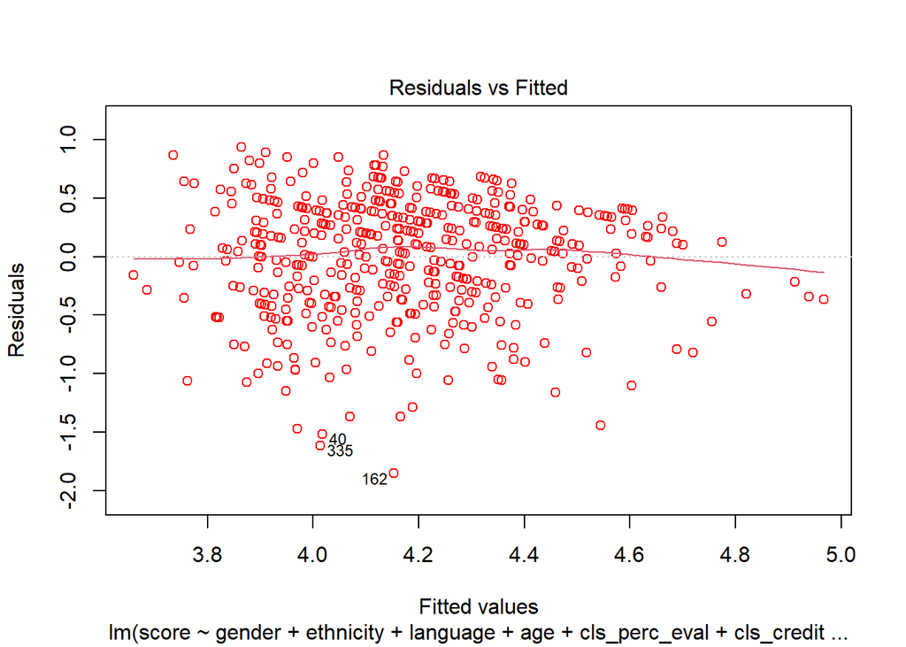

```r
#hist(m_full$residuals, prob = TRUE, breaks = 11,  main = "m_full-residuals", xlab = "Residual")
#lines(density(m_full$residuals, adjust = 1.8), col = "Red", lwd = 2)

#plot(m_full)
plot(m_full, which = 1, col = c("red"))
```

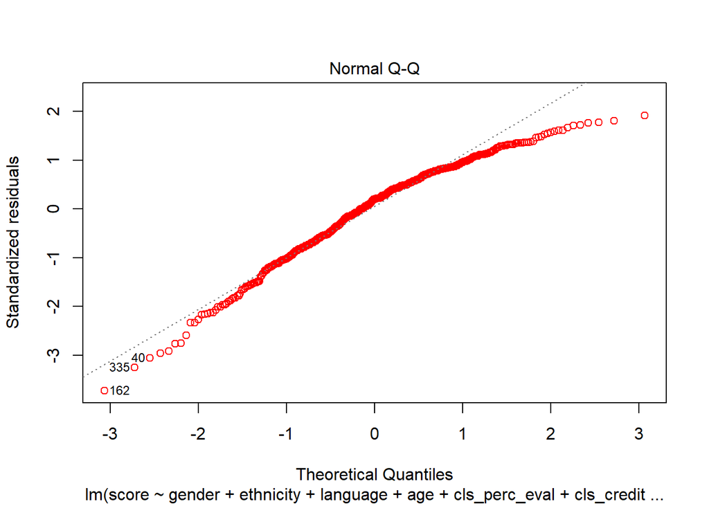

```r
plot(m_full, which = 2, col = c("red"))
```

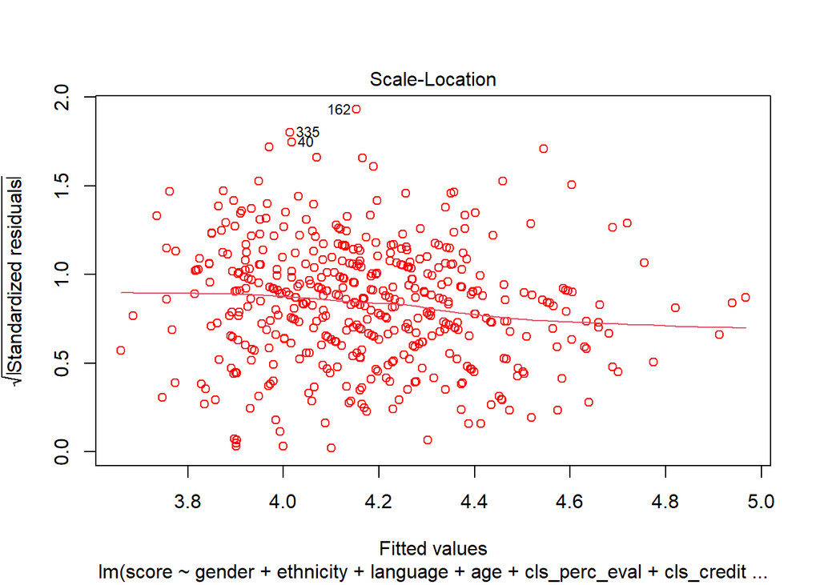

```r
plot(m_full, which = 3, col = c("red"))
```

#### Answer: Based on the Normal Q-Q plots the residual of the model appears nearly normal (slightly left skewed). We really don’t see outliers , however, the tails are off line

Variability of the residuals is nearly constant: Based on the scale-location plot, we see that the residuals are equaly spread along the ranges of predictors. Each variable is linearly related to the outcome: based on the Residuals vs Fitted plot, there is no distinct patterns, so we are tempted to say we don’t have non-linear relationship, however, the spread in the residuals is not equally distributed around the horizontal line. It looks like we have a “V” form.

## Exercice 17

17. The original paper describes how these data were gathered by taking a sample of professors from the University of Texas at Austin and including all courses that they have taught. Considering that each row represents a course, could this new information have an impact on any of the conditions of linear regression? #### Answer: Yes and no, if each row represents a course, then we would like to know whether there are students who take one course or multiple courses and whether there are professors who teach more than one class. The assumption is that a student taking only one course might have a different opinio than the same student taking 02 courses with the same professor. It is hard to have the same goodness on two different topics.

## Exercice 19

19. Would you be comfortable generalizing your conclusions to apply to professors generally (at any university)? Why or why not? #### Answer: No, we Wouldn’t be comfortable generalizing our conclusions to apply to professors generally (at any university). there is a bias in the assumption. Generalizing these conclusions would mean students are about the same all region. Whereas, how students appreciate a teacher is more a sociology/psychology aspect than it is a scientific law. For example, Students who go to school in the region where graduation and retention rate are very high would have a different feedback than those who go to school in the region where graduation and retention rate are very low.

## References

This work is licensed under a [Creative Commons Attribution-ShareAlike 4.0 International License](http://creativecommons.org/licenses/by-sa/4.0/).

https://fall2020.data606.net/assignments/labs/

https://www.statisticshowto.com/least-squares-regression-line/